# Example: Linear Model with World Bank Data

Burak Can Serdar

2023-09-29

## Introduction

In this analysis, we explore the relationship between two significant factors: PISA Reading Scores and Education Expenditure as a percentage of Gross Domestic Product (GDP). We aim to determine whether there exists a statistically significant association between these two variables. The analysis employs a Linear Regression Model, allowing us to examine the influence of Education Expenditure on PISA Reading Scores for various countries. The model’s coefficients and statistical insights will provide valuable information on the relationship between these variables.

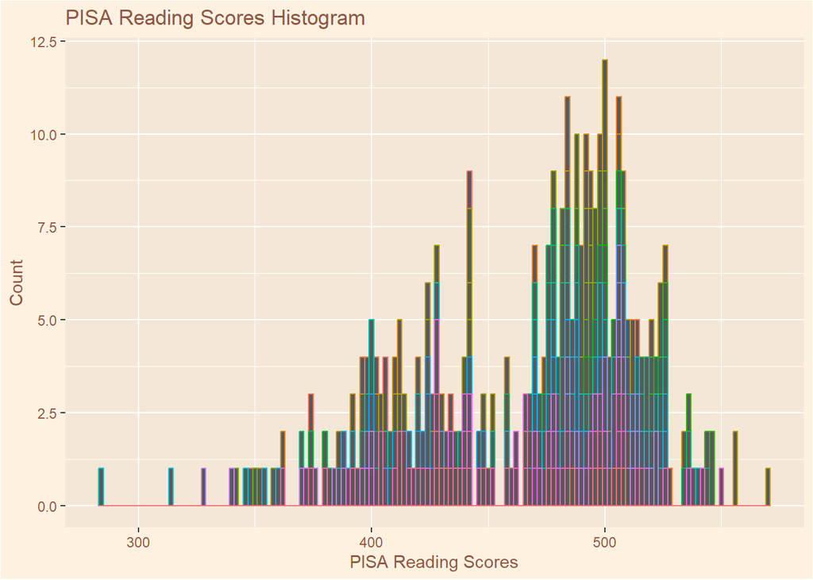

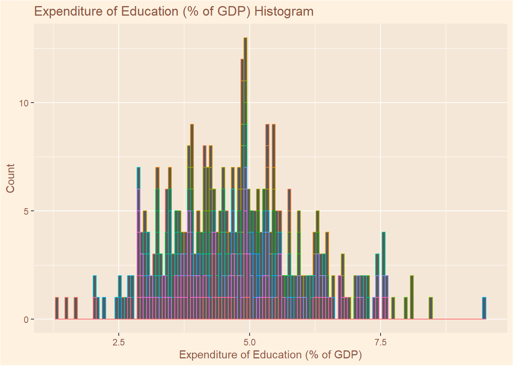

To begin our analysis, we obtain data from the World Bank API. We have chosen to investigate two key indicators: PISA Reading Scores and Education Expenditure (% of GDP). To efficiently retrieve data from the API, we have created a custom R function, `get_specific_id`. This function constructs the appropriate URL and fetches data from the World Bank API. It also saves the data as RDS files for later use. Additionally, we provide a function, `search_id`, to search for specific World Bank indicators based on keywords.

## Getting Data

#### GET function

We can use this function to get data from Worldbank API:

```r
library(tidyverse)
library(httr)
library(jsonlite)

get_specific_id <- function(country_1_code, indicator_code, number_values = 20000) {
  url <- paste0("https://api.worldbank.org/v2/country/", country_1_code, "/indicator/", indicator_code, "?format=json&per_page=", number_values) # forms an URL based on what we want in arguments

  result <- GET(url) # We use the URL to GET the result

  if (http_type(result) == "application/json") { # IF ordinary API response
    data <- content(result, as = "text") %>%
      fromJSON() %>%
      .[[2]] %>% # generally the juicy parts are at [2]
      na.omit(value) %>% # cleaning rows with NA values
      as_tibble()

    df_name_var <- paste0(indicator_code, "_", country_1_code) # dynamic dataframe name based on indicator and country
    assign(df_name_var, data, envir = .GlobalEnv) # assigns data to that dataframe and to environment
    saveRDS(data, file = paste0("./rds/", df_name_var, "_", Sys.Date(), ".rds")) # and outputs with a dynamic filename

  } else { # ELSE with erroneous API response
    error_msg <- content(result, as = "text")
    cat("API Error:", error_msg, "\n")
    return(NULL)
  }
}
```

#### Finding Indicator Codes

```r
library(tidyverse)
library(httr)
library(jsonlite)

id_list <-
  GET("https://api.worldbank.org/v2/indicator?format=json&per_page=21020") %>%
  content(as = "text") %>%
  fromJSON() %>%
  .[[2]] %>%
  select(id, name, sourceNote) %>%  # sourceNote gives useful short explanations on indicators, better keep them
  rename(id_code = id, id_name = name, id_about = sourceNote) %>% # modifies to more useful column names
  select(id_code, id_name, id_about) %>%
  as_tibble()

save(id_list,
     file = "id_list.rda") # outputs as rda
```

#### Searching through Indicators

It seems there are 21020 of them. We need a way to search to quickly browse through them. This function searches through the names of indicators for a maximum of 3 words bound with logical AND:

```r
library(tidyverse)

search_id <- function(param_1, param_2 = NULL, param_3 = NULL) {
  load("id_list.rda")

  search_result <- id_list %>%
    filter(
      str_detect(id_name, regex(param_1, ignore_case = TRUE)) &
        if (!is.null(param_2)) str_detect(id_name, regex(param_2, ignore_case = TRUE)) else TRUE &
        if (!is.null(param_3)) str_detect(id_name, regex(param_3, ignore_case = TRUE)) else TRUE
    ) %>%
    select(id_code, id_name, id_about) %>%
    as_tibble()

  assign("search_result", search_result, envir = .GlobalEnv) # this creates a tibble named search_results on global environment

  return(search_result)
}
```

## Preparing Data

After obtaining the data, we import it into R as data frames, creating two essential data sets: PISA Reading Scores and Education Expenditure. These data sets are saved as RDS files to ensure easy access for future analysis. We also perform initial data cleaning and join these data sets based on common country-date pairs, creating a comprehensive data set for our analysis. The data preparation phase ensures that we work with high-quality data for our regression analysis.

We chose our indicators PISA reading scores (LO.PISA.REA_all_2023-09-30.rds) and education expenditures (SE.XPD.TOTL.GD.ZS_all_2023-09-30.rds), got them, and saved them.

We could do all this dynamically, getting data in real-time from the API, but it will cause unnecessary delay in each run of our code and put a load on the remote server. The data we are getting is not that dynamic anyway, so it does not make sense to check it for updates in each run.

Now that we have the RDS files, we will import them to R as data frames:

```r
pisa_results <- readRDS("./rds/LO.PISA.REA_all_2023-09-30.rds") # assigning pisa as dataframe
```

PISA dataframe looks like this:

```
## # A tibble: 6 × 8
##   indicator$id country$id countryiso3code date  value unit  obs_status decimal
##   <chr>        <chr>      <chr>           <chr> <dbl> <chr> <chr>        <int>
## 1 LO.PISA.REA  OE         OED             2018   487. ""    ""               0
## 2 LO.PISA.REA  AL         ALB             2018   405. ""    ""               0
## 3 LO.PISA.REA  AL         ALB             2015   405. ""    ""               0
## 4 LO.PISA.REA  AL         ALB             2012   394. ""    ""               0
## 5 LO.PISA.REA  AL         ALB             2009   385. ""    ""               0
## 6 LO.PISA.REA  AL         ALB             2000   349. ""    ""               0
## # ℹ 2 more variables: indicator$value <chr>, country$value <chr>
```

Do the same to expenditures:

```r
expenditure <- readRDS("./rds/SE.XPD.TOTL.GD.ZS_all_2023-09-30.rds") # assigning expenditures as dataframe
```

And expenditures look like this:

```
## # A tibble: 6 × 8
##   indicator$id   country$id countryiso3code date  value unit  obs_status decimal
##   <chr>          <chr>      <chr>           <chr> <dbl> <chr> <chr>        <int>
## 1 SE.XPD.TOTL.G… ZH         AFE             2020   4.61 ""    ""               1
## 2 SE.XPD.TOTL.G… ZH         AFE             2019   4.60 ""    ""               1
## 3 SE.XPD.TOTL.G… ZH         AFE             2018   4.83 ""    ""               1
## 4 SE.XPD.TOTL.G… ZH         AFE             2017   4.86 ""    ""               1
## 5 SE.XPD.TOTL.G… ZH         AFE             2016   4.82 ""    ""               1
## 6 SE.XPD.TOTL.G… ZH         AFE             2015   4.82 ""    ""               1
## # ℹ 2 more variables: indicator$value <chr>, country$value <chr>
```

#### Join

Now that we have our pisa_results and expenditure data frames, we will prepare these data for our analysis. A quick glance shows us that some country-date data overlaps in both data frames, and some do not. We will only use countries and dates that exist in both data; therefore, we have to do an inner join. Before that, some fine-tuning in our data frames like changing the column names so that we will know which columns are which after the join:

```r
cleaned_pisa <- pisa_results %>% # preparing the dataframe for join
  mutate(country = countryiso3code) %>%
  rename(value_pisa = value) %>%
  select(country, date, value_pisa)

cleaned_exp <- expenditure %>% # preparing the dataframe for join
  mutate(country = countryiso3code) %>%
  rename(value_exp = value) %>%
  select(country, date, value_exp)
joined <- inner_join(cleaned_pisa, cleaned_exp, by = c("country", "date")) # inner joining the two dataframes by their "country" and "date" column

rm(list = c("pisa_results", "expenditure", "cleaned_pisa", "cleaned_exp")) # we won't need all those dataframes we created anymore.
```

The joined data frame looks like this:

```
## # A tibble: 6 × 4
##   country date  value_pisa value_exp
##   <chr>   <chr>      <dbl>     <dbl>
## 1 OED     2018        487.      4.90
## 2 ALB     2018        405.      3.15
## 3 ALB     2015        405.      3.44
## 4 ALB     2012        394.      2.93
## 5 ALB     2000        349.      3.43
## 6 DZA     2015        350.      7.96
```

## Analysis

In this section, we delve into the heart of our investigation, exploring the relationship between two variables—PISA Reading Scores and Education Expenditure. We aim to determine whether there is a statistically significant association between these two factors.

#### Linear Regression Model

To conduct this analysis, we employ a Linear Regression Model. This model allows us to examine the influence of Education Expenditure (measured as a percentage of GDP) on PISA Reading Scores for various countries.

In the context of our linear regression model, the equation can be expressed as:

$$PISA \, Reading \, Scores = \beta_0 +
\beta_1 \times Education \, Expenditure$$

Where:

- $PISA \, Reading \, Scores$ represent the performance in reading assessments.
- $Education \, Expenditure$ is the financial investment made in education as a percentage of a country’s Gross Domestic Product (GDP).
- $\beta_0$ denotes the intercept, which represents the predicted value of PISA Reading Scores when Education Expenditure is zero.
- $\beta_1$ signifies the coefficient for Education Expenditure, indicating the change in PISA Reading Scores for a one-unit change in Education Expenditure.

```r
model <- lm(value_pisa ~value_exp, joined) # This is the part we actually create our model. we ask if "value_pisa" values depend on "value_exp" values in the "joined" dataframe.
summary(model)
```

```
##
## Call:
## lm(formula = value_pisa ~ value_exp, data = joined)
##
## Residuals:
##     Min      1Q  Median      3Q     Max
## -186.94  -36.96   12.93   32.74  109.91
##
## Coefficients:
##             Estimate Std. Error t value Pr(>|t|)
## (Intercept)  426.538      9.681  44.057  < 2e-16 ***
## value_exp      8.128      1.956   4.154 4.08e-05 ***
## ---
## Signif. codes:  0 '***' 0.001 '**' 0.01 '*' 0.05 '.' 0.1 ' ' 1
##
## Residual standard error: 49.36 on 357 degrees of freedom
## Multiple R-squared:  0.04612,    Adjusted R-squared:  0.04344
## F-statistic: 17.26 on 1 and 357 DF,  p-value: 4.085e-05
```

#### Statistical Insights

Upon running the linear regression model, we receive valuable insights into the relationship between these variables. The summary of the model provides us with key statistics:

- Residuals: These show the differences between the actual PISA Reading Scores and the scores predicted by the model.
- Coefficients: The coefficients estimate the effects of Education Expenditure on PISA Reading Scores.
  - The coefficient for Education Expenditure $(\beta_1)$ tells us how much PISA Reading Scores are expected to change for a one-unit increase in Education Expenditure.
- Residual Standard Error: This measures the typical error in the model’s predictions.
- R-squared: The coefficient of determination indicates the proportion of the variance in PISA Reading Scores explained by Education Expenditure.
- F-statistic: This statistic assesses the overall significance of the model.

#### Visualization

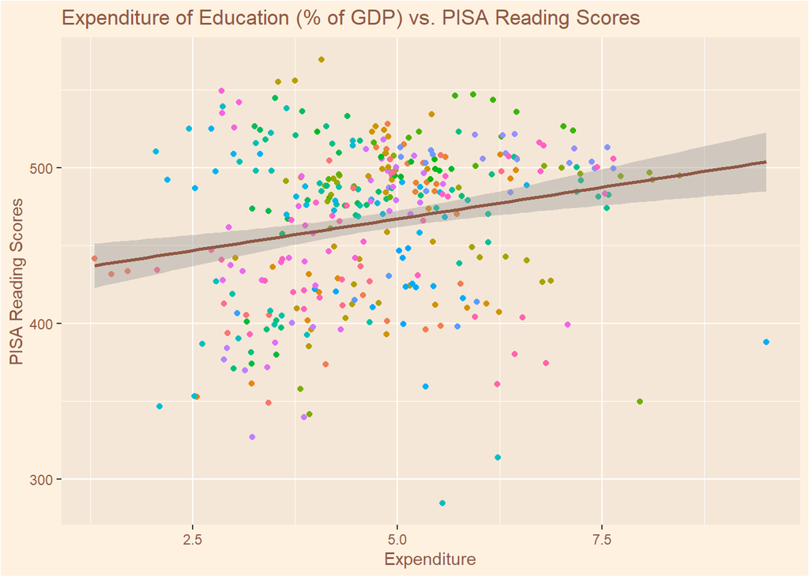

#### Conclusion

In this analysis, we’ve conducted a regression analysis in R to examine the relationship between PISA Reading Scores and Education Expenditure as a percentage of Gross Domestic Product (GDP). Our goal was to demonstrate the step-by-step process of conducting a regression analysis and drawing meaningful conclusions.

To kickstart our analysis, we began by introducing the context and purpose of our study. We aimed to understand whether there’s a statistically significant association between PISA Reading Scores and Education Expenditure, which is crucial for making informed decisions in the field of education.

Before diving into the analysis, we showed how to efficiently retrieve data from the World Bank API. We introduced a custom R function, `get_specific_id`, which allows us to fetch relevant data, saving it as RDS files for easy access in the future. Additionally, we provided the `search_id` function to search for specific World Bank indicators based on keywords.

Next, we imported the obtained data into R as data frames, creating two essential data sets: PISA Reading Scores and Education Expenditure. These data sets were saved as RDS files for easy access in subsequent analysis. We conducted initial data cleaning and merged these data sets based on common country-date pairs, creating a comprehensive data set for our analysis.

In the analysis section, we delved into the core of our investigation—the relationship between PISA Reading Scores and Education Expenditure. We highlighted the use of a Linear Regression Model to assess the influence of Education Expenditure on PISA Reading Scores for different countries.

We presented the results of our regression analysis, including crucial statistical insights: - Residuals: Differences between actual and predicted PISA Reading Scores. - Coefficients: The effect of Education Expenditure on PISA Reading Scores. - Residual Standard Error: The typical error in the model’s predictions. - R-squared: The proportion of variance in PISA Reading Scores explained by Education Expenditure. - F-statistic: Assessing the overall significance of the model.

Our analysis isn’t just an academic exercise; it has real-world implications. The insights we’ve gained into the connection between Education Expenditure and PISA Reading Scores can inform policymakers, educators, and researchers. Understanding the impact of financial investment in education on student performance in reading assessments is crucial for making informed decisions in the education sector.

In summary, our regression analysis in R serves as a practical example of how to explore and draw meaningful conclusions from real-world data. This step-by-step guide demonstrates the entire process, from data retrieval to visualization, providing a solid foundation for conducting regression analyses in R. By following this example, you can apply similar techniques to your own research, data analysis, and decision-making endeavors.

### Burak Can Serdar - 2023 - All Rights Reserved